# MTH 209

Analysis of The Roller Coaster Data

Evan McClelland  
Mechanical Engineering Student  
University of Dayton

2024-10-29

# Question 1

**Read the data file: Roller_Coasters_Data.csv. How many observations do we have in this data?**

```
## [1] "There are 145 observations"
```

# Question 2

**Get a glimpse of the data. How many variables do we have in the data?**

```
## Rows: 145
## Columns: 13
## $ Coaster    <chr> "Afterburner", "Alpengeist", "American Eagle", "Anaconda", …
## $ Park       <chr> "Fun Spot", "Busch Gardens Williamsburg", "Six Flags Great …
## $ City       <chr> "Angola", "Williamsburg", "Gurnee", "Doswell", "Williamsbur…
## $ State      <chr> "Indiana", "Virginia", "Illinois", "Virginia", "Virginia", …
## $ Type       <chr> "Steel", "Steel", "Wooden", "Steel", "Steel", "Wooden", "St…
## $ Design     <chr> "Sit Down", "Inverted", "Sit Down", "Sit Down", "Sit Down",…
## $ Opened     <int> 1991, 1997, 1981, 1991, 1999, 2000, 1998, 1998, 2000, 1993,…
## $ Speed      <int> 45, 67, 66, 50, 73, NA, 70, 70, 65, 55, 50, 65, 37, 48, 40,…
## $ Height     <int> 56, 195, 127, 128, 170, 95, 200, 200, 157, 90, 105, 110, 32…
## $ Drop       <int> 47, 170, 147, 144, 210, 92, 139, 105, 148, 85, 80, 141, 41,…
## $ Length     <int> 635, 3828, 4650, 2700, 4882, 3340, 1137, 1229, 4210, 2300, …
## $ Inversions <int> 1, NA, 0, 4, 0, 0, 2, 3, 5, 1, 5, 0, 0, 0, 0, 0, 0, 1, 0, 4…
## $ Age_Group  <chr> "2:middle", "2:middle", "1:older", "2:middle", "3:newer", "…
```

```
## [1] "There are 13 variables"
```

# Question 3

**Create a bar plot of Design of Roller Coasters. Use a few sentences to summarize your finding based on the plot.**

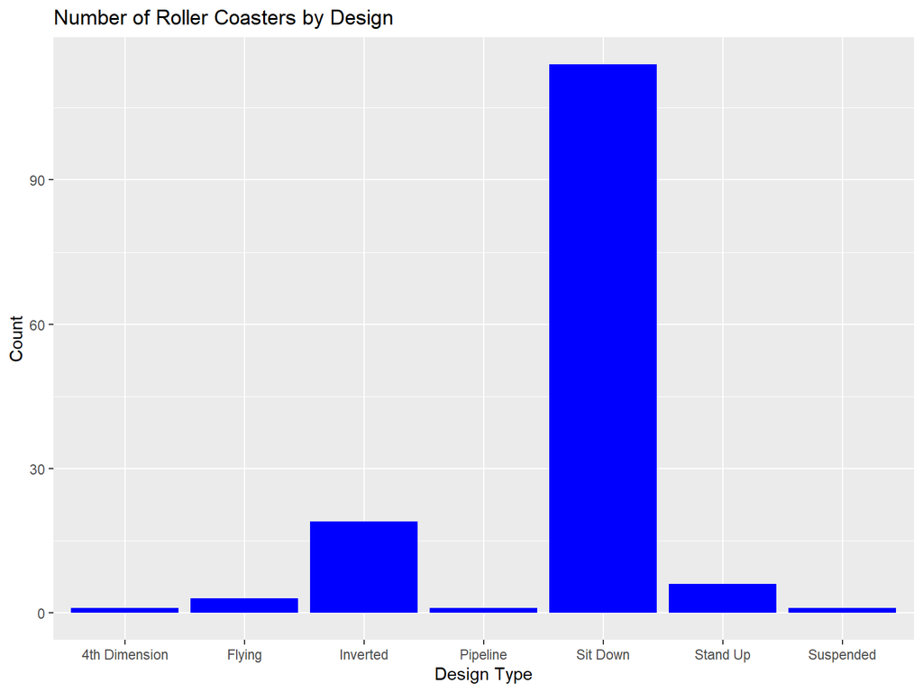

Overall the sit down design for roller coasters is a lot higher than any other design.

# Question 4

**Create a pie chart of Type of Roller Coasters. Use one sentence to summarize your finding based on the plot.**

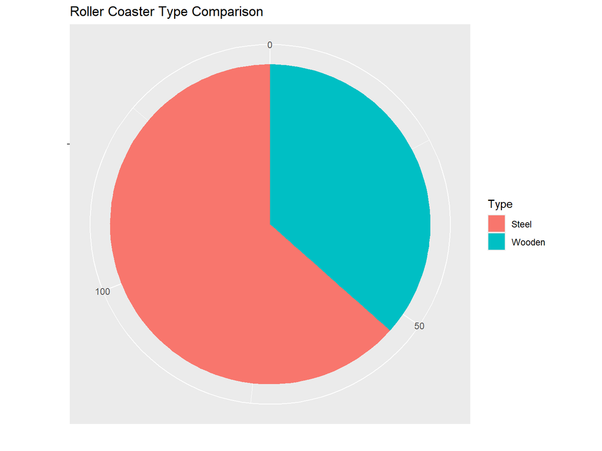

Overall there are more steel roller coasters than wooden roller coasters.

# Question 5

**Create a histogram of Speed of Roller Coasters. Comment on the distribution of the histogram. You should focus on shape, center, spread, and if there are any unusual features.**

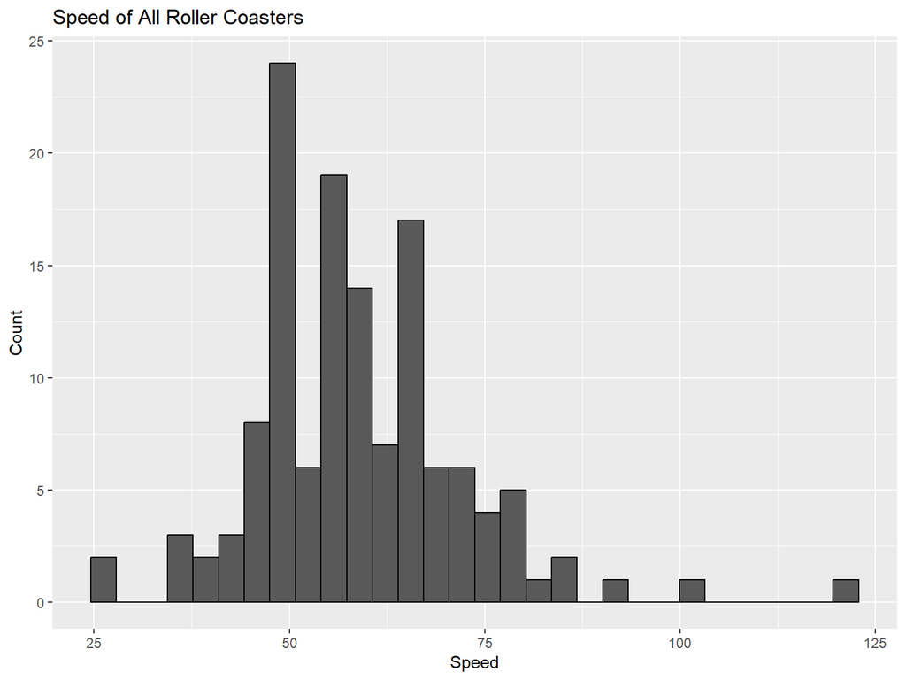

# Question 6

**Create a boxplot of Speed by Design. Comment on the distributions of maximum speed among different designs of roller coasters.**

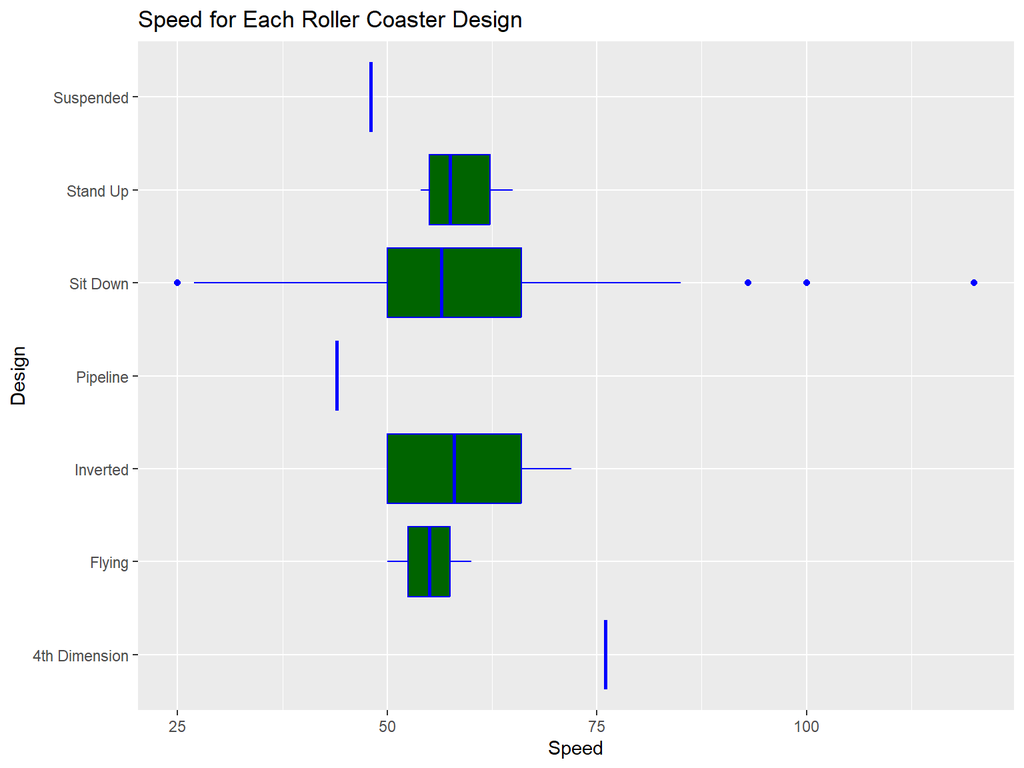

The sit down design of the RC has a lot more variability in speed than all the other Rcs. The other designs have a not as many Rcs so that is why they don’t have as large variability.

# Question 7

**Create a boxplot of Speed by Age_Group. Comment on the distributions of maximum speed among different age groups of roller coasters.**

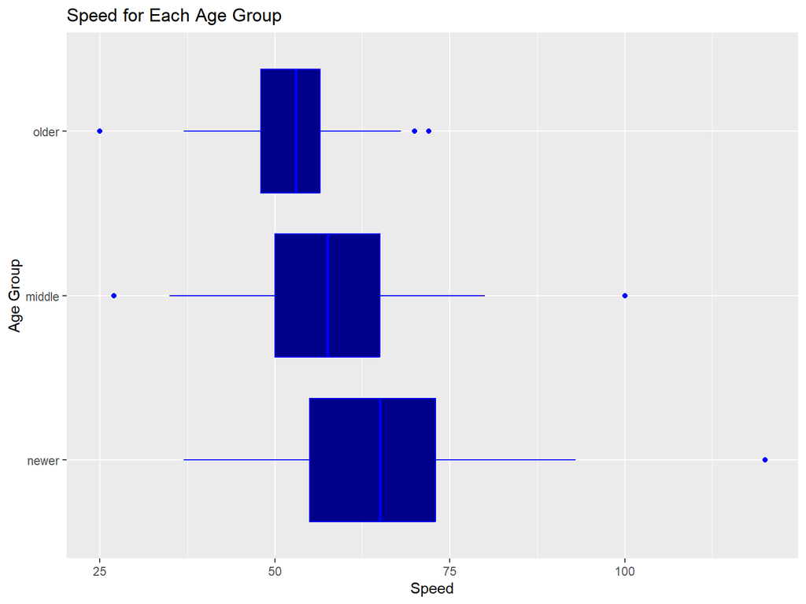

# Question 8

**a. Create a scatterplot of Speed (y) against Height. Comment on the scatterplot.**  
**b. Create a scatterplot of Speed (y) against Drop**  
**c. Which variable (Height or Drop) is a better predictor of the maximum speed? Why?**

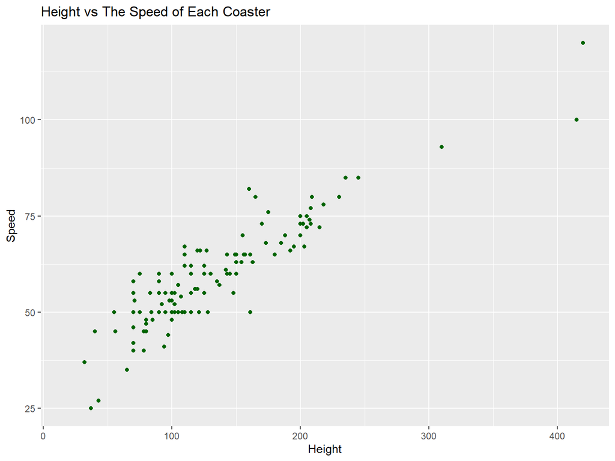

As Height increases so does the speed of the coaster.

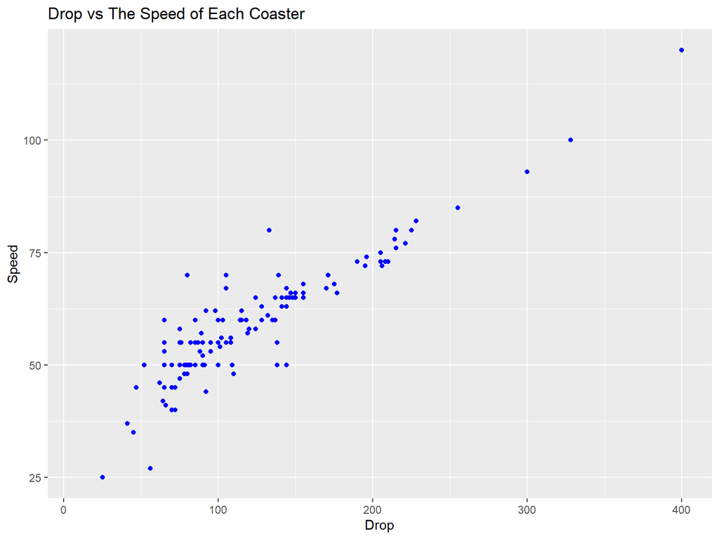

The better predictor for max speed is Drop because the cluster of points is closer in the Drop vs speed than the height vs speed